# Notebook

## With "D.A.S_FormattedActivityDate" dataframe:

### i. Calculate the Overall amount of Calories burnt per activity days, Group by ActivityDate, sorted by sum_Calories in a Descending order.

```r
TotalCalories_Per_Day_Overall_IDs <- D.A.S_FormattedActivityDate %>%
  group_by(ActivityDate) %>%
  summarize(., sum_Calories = sum(Calories)) %>% arrange(desc(sum_Calories))
TotalCalories_Per_Day_Overall_IDs
```

A tibble: 31 × 2

| ActivityDate <chr> | sum_Calories <int> |
| --- | --- |
| 4/15/2016Fri | 77721 |
| 4/12/2016Tue | 75556 |
| 4/16/2016Sat | 74510 |
| 4/14/2016Thu | 74489 |
| 4/18/2016Mon | 72980 |
| 4/20/2016Wed | 72604 |
| 4/22/2016Fri | 72505 |
| 4/28/2016Thu | 72134 |
| 4/13/2016Wed | 71982 |
| 4/23/2016Sat | 70224 |
| 4/24/2016Sun | 69999 |
| 5/3/2016Tue | 69667 |
| 4/21/2016Thu | 69555 |
| 4/30/2016Sat | 69548 |
| 4/26/2016Tue | 69217 |
| 4/25/2016Mon | 68674 |
| 4/19/2016Tue | 67919 |
| 4/27/2016Wed | 67282 |
| 5/6/2016Fri | 67189 |
| 4/17/2016Sun | 66011 |
| 4/29/2016Fri | 64778 |
| 5/5/2016Thu | 64445 |
| 5/1/2016Sun | 62916 |
| 5/4/2016Wed | 62813 |
| 5/2/2016Mon | 62799 |
| 5/7/2016Sat | 60167 |
| 5/9/2016Mon | 57965 |
| 5/8/2016Sun | 55276 |
| 5/10/2016Tue | 54496 |
| 5/11/2016Wed | 49152 |
| 5/12/2016Thu | 21877 |

### ii. Calculate the Mean Value of the Overall amount of Calories burnt per activity days, Grouped by ActivityDate, sorted by mean_Calories in a Descending order.

```r
MeanCalories_Overall_IDs <- D.A.S_FormattedActivityDate %>%
  group_by(ActivityDate) %>%
  summarize(., mean_Calories = mean(Calories)) %>% arrange(desc(mean_Calories))
MeanCalories_Overall_IDs
```

A tibble: 31 × 2

| ActivityDate <chr> | mean_Calories <dbl> |
| --- | --- |
| 5/3/2016Tue | 2488.107 |
| 4/21/2016Thu | 2484.107 |
| 4/30/2016Sat | 2483.857 |
| 5/5/2016Thu | 2478.654 |
| 5/10/2016Tue | 2477.091 |
| 4/25/2016Mon | 2452.643 |
| 4/12/2016Tue | 2437.290 |
| 4/19/2016Tue | 2425.679 |
| 4/23/2016Sat | 2421.517 |
| 4/20/2016Wed | 2420.133 |
| 5/9/2016Mon | 2415.208 |
| 5/7/2016Sat | 2406.680 |
| 4/16/2016Sat | 2403.548 |
| 5/8/2016Sun | 2403.304 |
| 4/27/2016Wed | 2402.929 |
| 4/14/2016Thu | 2402.871 |
| 5/6/2016Fri | 2399.607 |
| 4/26/2016Tue | 2386.793 |
| 4/15/2016Fri | 2355.182 |
| 4/18/2016Mon | 2354.194 |
| 4/22/2016Fri | 2338.871 |
| 4/24/2016Sun | 2333.300 |
| 4/28/2016Thu | 2326.903 |
| 5/4/2016Wed | 2326.407 |
| 5/2/2016Mon | 2325.889 |
| 4/13/2016Wed | 2322.000 |
| 4/29/2016Fri | 2313.500 |
| 4/17/2016Sun | 2276.241 |
| 5/1/2016Sun | 2247.000 |
| 5/11/2016Wed | 2234.182 |
| 5/12/2016Thu | 1286.882 |

### iii. Calculate the Mean Value of the Overall amount of Calories burnt

```r
MeanCalories <- D.A.S_FormattedActivityDate %>%
  summarize(., mean_Calories = mean(Calories))
MeanCalories
```

A data.frame: 1 × 1

| mean_Calories <dbl> |
| --- |
| 2362.471 |

```r
TotalCalories_Per_ID <- D.A.S_FormattedActivityDate %>%
  group_by(Id) %>%
  summarize(., sum_Calories = sum(Calories), sum_TotalDistance.by.Tracker= sum(TotalDistance.by.Tracker))
TotalCalories_Per_ID
```

A tibble: 33 × 3

| Id <dbl> | sum_Calories <int> | sum_TotalDistance.by.Tracker <dbl> |
| --- | --- | --- |
| 1503960366 | 56309 | 242.10 |
| 1624580081 | 45984 | 121.36 |
| 1644430081 | 84339 | 158.86 |
| 1844505072 | 34641 | 52.89 |
| 1927972279 | 39152 | 19.67 |
| 2022484408 | 77809 | 250.61 |
| 2026352035 | 47760 | 107.10 |
| 2320127002 | 53449 | 98.82 |
| 2347167796 | 36782 | 114.40 |
| 2873212765 | 59426 | 158.15 |
| 3372868164 | 38662 | 94.14 |
| 3977333714 | 45410 | 225.51 |
| 4020332650 | 46239 | 50.41 |
| 4057192912 | 6119 | 11.45 |
| 4319703577 | 63168 | 151.66 |
| 4388161847 | 95910 | 260.19 |
| 4445114986 | 67772 | 100.62 |
| 4558609924 | 63031 | 157.50 |
| 4702921684 | 89915 | 215.61 |
| 5553957443 | 58146 | 174.83 |
| 5577150313 | 97151 | 186.40 |
| 6117666160 | 55831 | 149.58 |
| 6290855005 | 66545 | 123.90 |
| 6775888955 | 38857 | 47.15 |
| 6962181067 | 61443 | 204.16 |
| 7007744171 | 64467 | 208.40 |
| 7086361926 | 77928 | 198.03 |
| 8053475328 | 91320 | 355.73 |
| 8253242879 | 33972 | 88.68 |
| 8378563200 | 106534 | 214.32 |
| 8583815059 | 84693 | 174.08 |
| 8792009665 | 41658 | 34.41 |
| 8877689391 | 106028 | 409.60 |

```r
Session_ID = c("ID_1", "ID_2", "ID_3", "ID_4", "ID_5", "ID_6", "ID_7", "ID_8", "ID_9", "ID_10", "ID_11", "ID_12", "ID_13", "ID_14", "ID_15", "ID_16", "ID_17", "ID_18", "ID_19", "ID_20", "ID_21", "ID_22", "ID_23", "ID_24", "ID_25", "ID_26", "ID_27", "ID_28", "ID_29", "ID_30", "ID_31", "ID_32", "ID_33")
TotalCalories_Per_ID <- cbind(TotalCalories_Per_ID, Session_ID)
```

```r
TotalCalories_Per_ID %>% arrange(desc(sum_Calories))
```

A data.frame: 33 × 4

| Id <dbl> | sum_Calories <int> | sum_TotalDistance.by.Tracker <dbl> | Session_ID <chr> |
| --- | --- | --- | --- |
| 8378563200 | 106534 | 214.32 | ID_30 |
| 8877689391 | 106028 | 409.60 | ID_33 |
| 5577150313 | 97151 | 186.40 | ID_21 |
| 4388161847 | 95910 | 260.19 | ID_16 |
| 8053475328 | 91320 | 355.73 | ID_28 |
| 4702921684 | 89915 | 215.61 | ID_19 |
| 8583815059 | 84693 | 174.08 | ID_31 |
| 1644430081 | 84339 | 158.86 | ID_3 |
| 7086361926 | 77928 | 198.03 | ID_27 |
| 2022484408 | 77809 | 250.61 | ID_6 |
| 4445114986 | 67772 | 100.62 | ID_17 |
| 6290855005 | 66545 | 123.90 | ID_23 |
| 7007744171 | 64467 | 208.40 | ID_26 |
| 4319703577 | 63168 | 151.66 | ID_15 |
| 4558609924 | 63031 | 157.50 | ID_18 |
| 6962181067 | 61443 | 204.16 | ID_25 |
| 2873212765 | 59426 | 158.15 | ID_10 |
| 5553957443 | 58146 | 174.83 | ID_20 |
| 1503960366 | 56309 | 242.10 | ID_1 |
| 6117666160 | 55831 | 149.58 | ID_22 |
| 2320127002 | 53449 | 98.82 | ID_8 |
| 2026352035 | 47760 | 107.10 | ID_7 |
| 4020332650 | 46239 | 50.41 | ID_13 |
| 1624580081 | 45984 | 121.36 | ID_2 |
| 3977333714 | 45410 | 225.51 | ID_12 |
| 8792009665 | 41658 | 34.41 | ID_32 |
| 1927972279 | 39152 | 19.67 | ID_5 |
| 6775888955 | 38857 | 47.15 | ID_24 |
| 3372868164 | 38662 | 94.14 | ID_11 |
| 2347167796 | 36782 | 114.40 | ID_9 |
| 1844505072 | 34641 | 52.89 | ID_4 |
| 8253242879 | 33972 | 88.68 | ID_29 |
| 4057192912 | 6119 | 11.45 | ID_14 |

### Observe the "TotalCalories_Per_ID" for Variance effect in each Participant's session productivity by Visualizing all the ID Activity development in Calorie-burn, using ggplot2

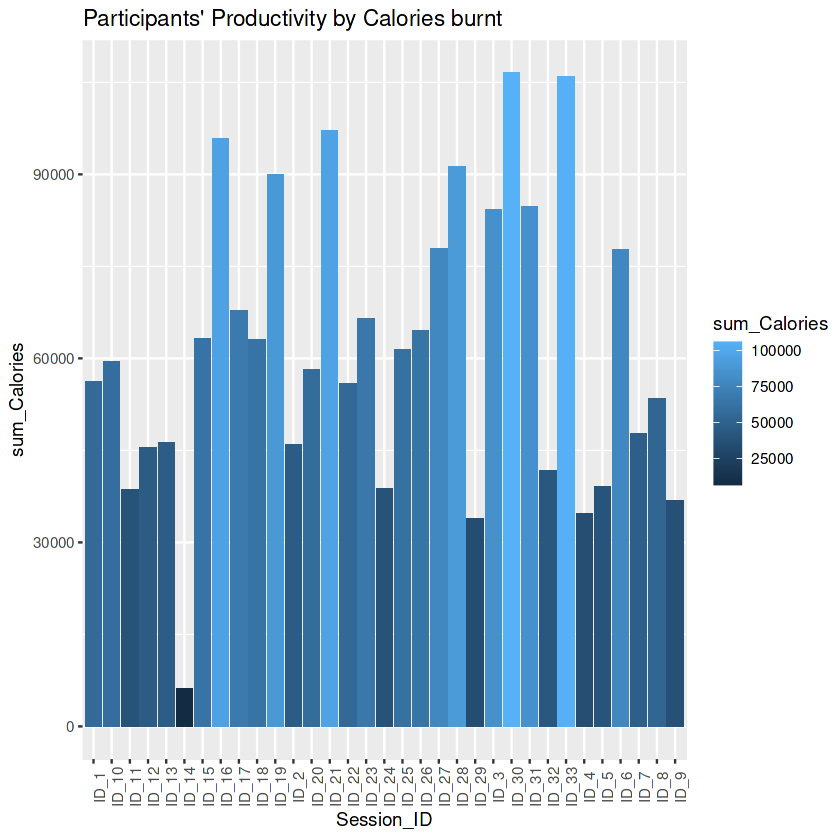

```r
ggplot(data=TotalCalories_Per_ID, aes(x=Session_ID, y=sum_Calories, fill=sum_Calories)) + geom_bar(stat="identity") + ggtitle("Participants' Productivity by Calories burnt") + theme(axis.text.x=element_text(angle=90))
```

**Note: The above Visualizaton proves that the Participant ID_30 and ID_33 have the most productive sessions with respect to the activity records by the Tracker, which takes us back to evaluate the activity logs of Participant ID_30 and ID_33**